# Multiple Linear Regression

Valentina Zangirolami (valentina.zangirolami@unimib.it)

2025-04-23

```r
#load libraries
library(car)
library(ggplot2)
library(tidyverse)
```

```r
esg_data <- read.csv("esg_financial_dataset.csv")
```

## *Dataset: ESG ratings*

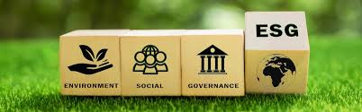

ESG (Environmental, Social, and Governance) refers to a set of criteria used to evaluate a company’s sustainability and ethical impact:

- **Environmental** – Impact on the natural environment (climate change, pollution, resource use).
- **Social** – Relationships with people (employees, communities, customers) focusing on diversity and human rights.
- **Governance** – Leadership ethics, transparency, shareholder rights, and anti-corruption policies in corporate decision-making.

ESG helps investors and customers assess whether a business operates responsibly for long-term success. The main ESG metric is the Overall ESG score which is computed as a weighted sum of Environmental score, Social score and Governance score.

```r
head(esg_data)
```

```
##   Industry        Region Revenue ProfitMargin MarketCap GrowthRate ESG_Overall
## 1   Retail Latin America   593.2          4.2     248.4       -1.8        57.7
## 2   Retail Latin America   636.7          5.3     373.9        7.3        57.8
## 3   Retail Latin America   687.0          4.6     460.1        7.9        58.5
## 4   Retail Latin America   734.5          5.0     628.8        6.9        59.2
## 5   Retail          Asia  3106.4          0.8     514.3       -1.9        64.0
## 6   Retail          Asia  3691.6         -0.7    2523.2       18.8        66.0
##   ESG_Environmental ESG_Social ESG_Governance CarbonEmissions WaterUsage
## 1              69.0       27.1           76.9         42536.3    21268.2
## 2              68.3       27.0           78.1         45956.3    22978.2
## 3              68.9       29.9           76.8         49289.1    24644.5
## 4              70.7       29.1           78.0         51805.8    25902.9
## 5              66.7       57.7           67.8        227761.4   113880.7
## 6              66.6       61.6           70.0        271015.1   135507.6
##   EnergyConsumption
## 1           85072.6
## 2           91912.6
## 3           98578.1
## 4          103611.7
## 5          455522.7
## 6          542030.3
```

There are 13 variables:

- **Industry**: Sector of the company
- **Region**: Region of the company
- **Revenue**: Annual revenue in millions USD
- **ProfitMargin**: Net profit margin as percentage of revenue
- **MarketCap**: Market capitalization in millions USD
- **GrowthRate**: Year-over-year revenue growth rate (%)
- **ESG_Overall**: Aggregate ESG sustainability score (0–100)
- **ESG_Environmental**: Environmental sustainability score (0–100)
- **ESG_Social**: Social responsibility score (0–100)
- **ESG_Governance**: Corporate governance quality score (0–100)
- **CarbonEmissions**: Annual carbon emissions in tons $CO_2$
- **WaterUsage**: Annual water usage in cubic meters
- **EnergyConsumption**: Annual energy consumption in megawatt-hours (MWh)

We exclude some variables to reduce the correlation among covariates (ESG Overall is generally a weighted sum of the other scores) and simplify the problem.

```r
cat_variables <- esg_data |> select(Industry)
esg_data <- esg_data |> select(-c(Industry, Region, ProfitMargin, ESG_Environmental, ESG_Social, ESG_Governance, EnergyConsumption, WaterUsage, CarbonEmissions))
```

Therefore, an appropriate regression model is represented by

$$MarketCap_i = \beta_1 + \beta_2
Revenue_i + \beta_3 GrowthRate_i + \beta_4 ESG\_Overall_i +
\epsilon_i$$
with the following assumptions:

- $\epsilon_i \overset{\text{i.i.d.}}{\sim} N(0, \sigma^2)$, $i=1, \ldots, 4000$
- Linear independence of covariates (Here, it is challenging)

*Answer*: When we have 2 covariates, the “right” plot should be the 3-dimensional plot. However, the main issue is the lower intepretability and it is just available in the case of 2 covariates. One way would be to represent our data through a Scatter matrix, keeping in mind we are just considering the marginal effect of each independent variable on the response (although with multiple regression we want to explain the combined effect). But it can be used with $k \ge 2$ covariates.

**Scatter plot Matrix**

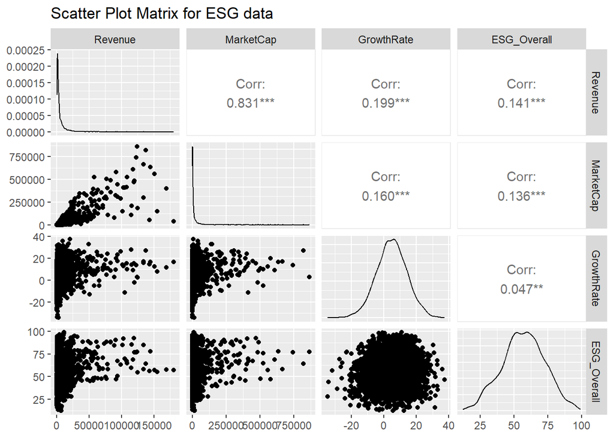

```r
Scatter_Matrix <- GGally::ggpairs(esg_data,
                          title = "Scatter Plot Matrix for ESG data",
                          axisLabels = "show")
```

**Marginal interpretation**

- *MarketCap vs Revenue*: the relationship among these two variables appears to be linear. Indeed, the linear correlation is really high.
- *MarketCap vs GrowthRate*: the relationship is not properly linear and the correlation is low.
- *MarketCap vs ESG_Score*: the relationship is not properly linear and the correlation is low.
- Relationship among independent variables: we can observe that the correlation among independent variables (GrowthRate-Revenue, ESG_Overall-Revenue, HP-ecc.) is not high, which represents a positive aspect in our case. Indeed, a marked linear dependence between independent variables leads to issues such as in the regression matrix X the corresponding columns are almost linearly dependent (multicollinearity). In the presence of multicollinearity, the estimates may be numerically unstable because the matrix $(X^TX)$ is nearly singular (a matrix is invertible iff it is nonsingular). $\implies$ a good model should not include pairs of highly correlated variables.

```r
mod <- lm(MarketCap~., data=esg_data)
summary(mod)
```

```
##
## Call:
## lm(formula = MarketCap ~ ., data = esg_data)
##
## Residuals:
##     Min      1Q  Median      3Q     Max
## -563332   -3288      84    2307  451075
##
## Coefficients:
##               Estimate Std. Error t value Pr(>|t|)
## (Intercept) -5.886e+03  1.735e+03  -3.393 0.000699 ***
## Revenue      3.349e+00  3.659e-02  91.535  < 2e-16 ***
## GrowthRate  -3.464e+01  5.021e+01  -0.690 0.490260
## ESG_Overall  6.662e+01  2.955e+01   2.254 0.024223 *
## ---
## Signif. codes:  0 '***' 0.001 '**' 0.01 '*' 0.05 '.' 0.1 ' ' 1
##
## Residual standard error: 29120 on 3996 degrees of freedom
## Multiple R-squared:  0.6907, Adjusted R-squared:  0.6905
## F-statistic:  2975 on 3 and 3996 DF,  p-value: < 2.2e-16
```

The estimated model corresponds to

$$\widehat{MarketCap}_i = -5885.75 + 3.35
Revenue_i - 34.64 GrowthRate_i + 66.62 ESG\_Overall_i$$
- **Coefficients:** In this section, we have 4 columns (Estimate, Std. Error, t-value, p-value). *Estimate* refers to the estimates of regression coefficients. *Std. Error* is the square root of the estimated variance of each estimator. The *t-value* is the test statistic of t-test with the related p-value.

Considering the following system of hypothesis
$$\begin{cases}
\mbox{H0: } \beta_r = 0\\
\mbox{H1: } \beta_r \ne 0
\end{cases}$$

for $r=\{1,2,3,4,5\}$. The t-values for $\beta_1$, $\beta_2$, $\beta_3$ and $\beta_4$ are $t_1^{oss} = -3.393$, $t_2^{oss} = 91.535$, $t_3^{oss} = -0.69$ and $t_4^{oss} = 2.254$.

- **Goodness of fit**: The last part of the output refers to checking the goodness of fit. In this case, the F-test has the following characteristics
  $$\begin{cases}
  \mbox{H0: } \beta_2 = \beta_3 =\beta_4 =0\\
  \mbox{H1: } \exists j \mbox{ s.t. }\beta_j \ne 0\mbox{, j=2,3,4}
  \end{cases}$$

The f-value is $f^{oss} = 2975$ and the p-value is $\alpha^{oss}= P(F_{3, 3996} > f^{oss}) \approx 0$. We reject the null hypothesis.

The coefficients of determination correspond to $R^2= 0.6907$ and $R_{(adj)}^2=0.6905$. The adjusted-$R^2$ is penalized by the number of covariates.

**Interpretation Coefficients**

- $\hat{\beta}_2 = 3.35$, the mean of MarketCap increases by 3.35 millions when Revenue increases by one million while keeping the other independent variables constant
- $\hat{\beta}_3 = -34.64$, the mean of MarketCap decreases by 34.64 millions when GrowthRate increases by 1% while keeping the other independent variables constant
- $\hat{\beta}_4 = 66.62$, the mean of MarketCap increases by 66.62 millions when ESG_Overall increases by one point-score while keeping the other independent variables constant

**Diagnostic plot**

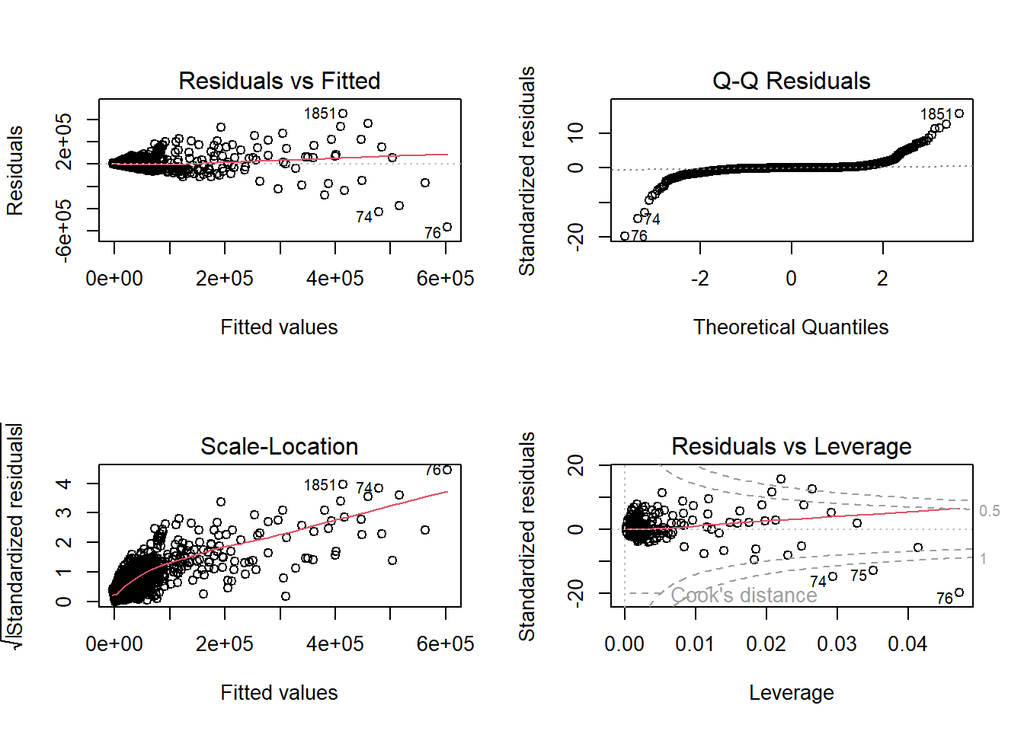

```r
par(mfrow=c(2,2))
plot(mod)
```

Comments:

- **Residual vs Fitted**: it seems that there is a slight pattern.. perhaps, linearity is not well satisfy
- **Q-Q Residuals**: heavy tails
- **Scale-Location**: it seems to show some concerns with homoscedasticity
- **Residuals vs Leverage**: there are two points with high leverage and there are few outliers. Some of these points are outside the cook’s distance and can affect estimates.

**Adding categorical variables**

When we add categorical variables in a linear model, we should know that they are handled with dummy variables. Let’s consider the following model

```r
esg_data <- cbind(esg_data, cat_variables)

mod_2 =lm(MarketCap~., data=esg_data)
summary(mod_2)
```

```
##
## Call:
## lm(formula = MarketCap ~ ., data = esg_data)
##
## Residuals:
##     Min      1Q  Median      3Q     Max
## -554493   -2304     756    3256  448656
##
## Coefficients:
##                          Estimate Std. Error t value Pr(>|t|)
## (Intercept)            -3.227e+03  2.177e+03  -1.482  0.13830
## Revenue                 3.156e+00  3.868e-02  81.578  < 2e-16 ***
## GrowthRate             -1.252e+02  4.913e+01  -2.548  0.01088 *
## ESG_Overall             1.686e+01  3.017e+01   0.559  0.57618
## IndustryEnergy         -3.991e+03  1.920e+03  -2.078  0.03777 *
## IndustryFinance        -5.397e+03  1.877e+03  -2.875  0.00406 **
## IndustryHealthcare      1.258e+03  1.824e+03   0.690  0.49038
## IndustryManufacturing  -1.108e+03  1.840e+03  -0.602  0.54708
## IndustryRetail         -8.559e+01  1.880e+03  -0.046  0.96369
## IndustryTechnology      2.792e+04  2.065e+03  13.521  < 2e-16 ***
## IndustryTransportation  1.018e+03  1.852e+03   0.550  0.58262
## IndustryUtilities       4.269e+00  1.886e+03   0.002  0.99819
## ---
## Signif. codes:  0 '***' 0.001 '**' 0.01 '*' 0.05 '.' 0.1 ' ' 1
##
## Residual standard error: 27970 on 3988 degrees of freedom
## Multiple R-squared:  0.7153, Adjusted R-squared:  0.7145
## F-statistic:   911 on 11 and 3988 DF,  p-value: < 2.2e-16
```

The estimated model corresponds to

$$\widehat{MarketCap}_i = -3227.37 + 3.16
Revenue_i -125.17 GrowthRate_i + 16.86 ESG\_Overall_i -3990.52 D_1
-5397.06 D_2 + 1257.97 D_3 -1108.29 D_4 -85.59 D_5 + 27922.22 D_6 +
1018.11 D_7 + 4.27 D_8$$
where, for $j=1, \ldots, 7$ and $cat=\{Energy, Finance, Healthcare, Manufacturing, Retail, Technology, Transportation, Utilities,Consumer Goods\}$,
$$D_j = \begin{cases}
1,\quad \mbox{ if } Industry =cat[j]\\
0,\quad \mbox{ Otherwise }
\end{cases}$$
Then, the category Consumer Goods is the baseline. We created 8 Dummies among 9 categories.

**Test about nested models**

We can compare the two models we have been considered: full model (with categorical variables) and the restricted model (with only quantitative variables).

```r
anova(mod, mod_2)
```

```
## Analysis of Variance Table
##
## Model 1: MarketCap ~ Revenue + GrowthRate + ESG_Overall
## Model 2: MarketCap ~ Revenue + GrowthRate + ESG_Overall + Industry
##   Res.Df        RSS Df  Sum of Sq      F    Pr(>F)
## 1   3996 3.3892e+12
## 2   3988 3.1197e+12  8 2.6953e+11 43.069 < 2.2e-16 ***
## ---
## Signif. codes:  0 '***' 0.001 '**' 0.01 '*' 0.05 '.' 0.1 ' ' 1
```

The null hypothesis is characterized by coefficients of dummies equal to 0.

**Residual Sum of Squares**

- Restricted model: $SSE= 3.3892e+12$
- Full model: $SSE= 3.1197e+12$

**Test statistic**

$$F^{obs}= 43.069$$
and the p-value is $\alpha^{obs} \approx 0$ $\implies$ We reject our null hypothesis $H0$.

**Diagnostic plot**

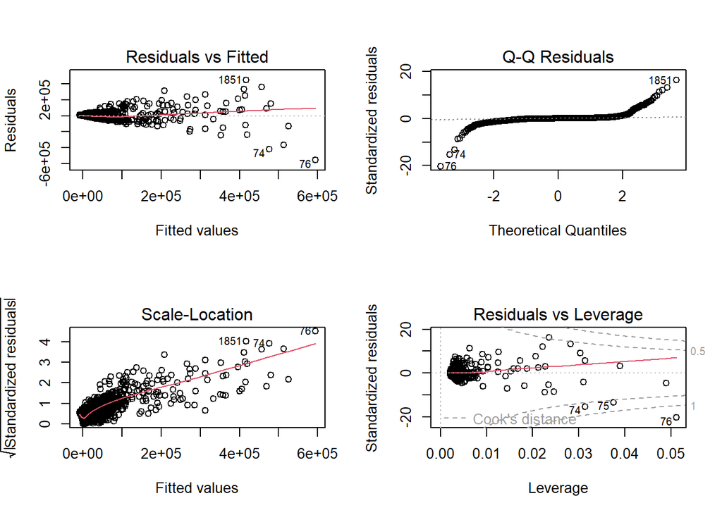

```r
par(mfrow=c(2,2))
plot(mod_2)
```

We can observe an improvement in terms of outliers while the conclusion of the other plots seems to be the same.

**Interaction**

We observe that there are few industry effects (such as Technology). To move beyond linearity, the first step can be adding interactions. Marginally, it could be interesting to visualize the relationship of GrowthRate-MarketCap-Industry and ESG_Overall-MarketCap-Industry

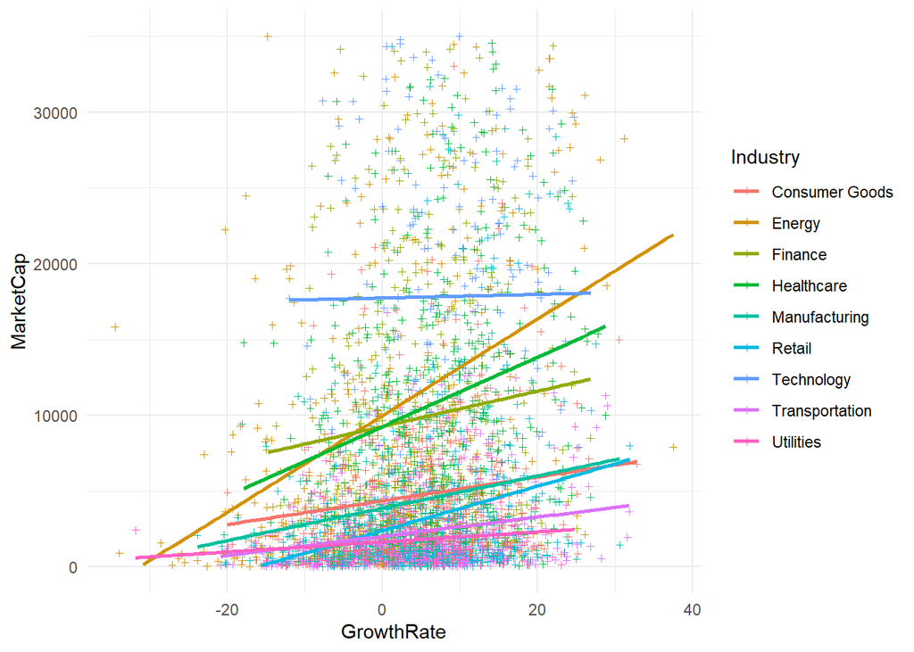

```r
ggplot(esg_data, aes(x = GrowthRate, y = MarketCap, color = Industry)) +
  geom_point(size = 1, shape=3) +
  geom_smooth(method = "lm", se = FALSE) +  # Adds linear regression lines
  labs(
    x = "GrowthRate",
    y = "MarketCap",
    color = "Industry"
  ) + ylim(0, 35000) +
  theme_minimal()
```

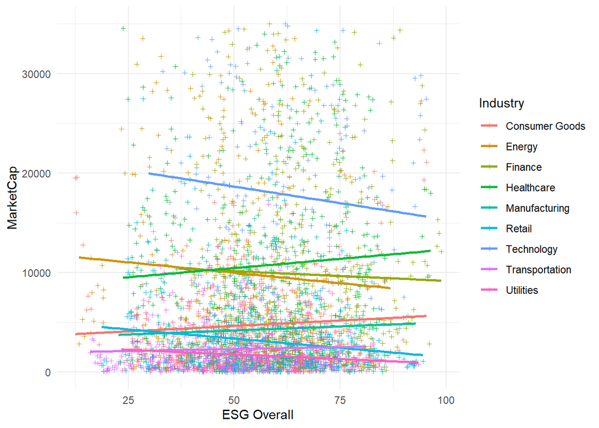

```r
ggplot(esg_data, aes(x = ESG_Overall, y = MarketCap, color = Industry)) +
  geom_point(size = 1, shape=3) +
  geom_smooth(method = "lm", se = FALSE) +  # Adds linear regression lines
  labs(
    x = "ESG Overall",
    y = "MarketCap",
    color = "Industry"
  ) + ylim(0, 35000) +
  theme_minimal()
```

No parallel lines. Let’s add the interaction GrowthRate-Industry

```r
mod_int <- lm(MarketCap ~ . + GrowthRate:Industry, data = esg_data)
summary(mod_int)
```

```
##
## Call:
## lm(formula = MarketCap ~ . + GrowthRate:Industry, data = esg_data)
##
## Residuals:
##     Min      1Q  Median      3Q     Max
## -560663   -2288     751    3012  451034
##
## Coefficients:
##                                     Estimate Std. Error t value Pr(>|t|)
## (Intercept)                       -3.331e+03  2.323e+03  -1.434   0.1516
## Revenue                            3.166e+00  3.922e-02  80.729   <2e-16 ***
## GrowthRate                        -8.711e+01  1.581e+02  -0.551   0.5816
## ESG_Overall                        1.445e+01  3.017e+01   0.479   0.6319
## IndustryEnergy                    -3.364e+03  2.112e+03  -1.593   0.1113
## IndustryFinance                   -4.279e+03  2.220e+03  -1.928   0.0540 .
## IndustryHealthcare                 1.707e+03  2.280e+03   0.749   0.4541
## IndustryManufacturing             -8.443e+02  2.103e+03  -0.402   0.6881
## IndustryRetail                    -4.133e+01  2.199e+03  -0.019   0.9850
## IndustryTechnology                 2.272e+04  2.722e+03   8.347   <2e-16 ***
## IndustryTransportation             1.017e+03  2.146e+03   0.474   0.6356
## IndustryUtilities                  5.309e+01  2.101e+03   0.025   0.9798
## GrowthRate:IndustryEnergy         -2.517e+02  1.908e+02  -1.319   0.1871
## GrowthRate:IndustryFinance        -2.367e+02  2.296e+02  -1.031   0.3027
## GrowthRate:IndustryHealthcare     -7.511e+01  2.149e+02  -0.349   0.7268
## GrowthRate:IndustryManufacturing  -5.583e+01  2.162e+02  -0.258   0.7962
## GrowthRate:IndustryRetail          2.717e-01  2.208e+02   0.001   0.9990
## GrowthRate:IndustryTechnology      5.377e+02  2.334e+02   2.304   0.0213 *
## GrowthRate:IndustryTransportation  6.332e+00  2.072e+02   0.031   0.9756
## GrowthRate:IndustryUtilities       5.091e+01  2.319e+02   0.220   0.8263
## ---
## Signif. codes:  0 '***' 0.001 '**' 0.01 '*' 0.05 '.' 0.1 ' ' 1
##
## Residual standard error: 27940 on 3980 degrees of freedom
## Multiple R-squared:  0.7166, Adjusted R-squared:  0.7152
## F-statistic: 529.6 on 19 and 3980 DF,  p-value: < 2.2e-16
```

The interaction between GrowthRate and Industry improves a bit the R-squared while making not significant GrowthRate.

#### **Model Selection**

Stepwise selection allows to select a model (which can contain a subset of features - that’s a way to select features) on the basis of the best value of a criterion.

There are three different ways: (i) **Backward selection**: starting from the full model, the feature are removed on the basis of a criterion; (ii) **Forward selection**: starting from the null model, the feature are added (one at a time) on the basis of a criterion; (iii) **Both**: forward and backward selection, starting from some plausible initial model (not necessarily the simplest or most complex). In each step add or drop one variable that most improves the model.

There main criterion is the Akaike Information Criteria:

$$AIC= -2 \sup \log Lik + 2 p$$

where $p$ is the number of coefficients.

```r
step(mod_int,trace=1,direction="backward")
```

```
## Start:  AIC=81921.36
## MarketCap ~ Revenue + GrowthRate + ESG_Overall + Industry + GrowthRate:Industry
##
##                       Df  Sum of Sq        RSS   AIC
## - ESG_Overall          1 1.7912e+08 3.1063e+12 81920
## <none>                              3.1061e+12 81921
## - GrowthRate:Industry  8 1.3552e+10 3.1197e+12 81923
## - Revenue              1 5.0862e+12 8.1923e+12 85799
##
## Step:  AIC=81919.59
## MarketCap ~ Revenue + GrowthRate + Industry + GrowthRate:Industry
##
##                       Df  Sum of Sq        RSS   AIC
## <none>                              3.1063e+12 81920
## - GrowthRate:Industry  8 1.3618e+10 3.1199e+12 81921
## - Revenue              1 5.1181e+12 8.2244e+12 85812
```

```
##
## Call:
## lm(formula = MarketCap ~ Revenue + GrowthRate + Industry + GrowthRate:Industry,
##     data = esg_data)
##
## Coefficients:
##                       (Intercept)                            Revenue
##                         -2513.776                              3.168
##                        GrowthRate                     IndustryEnergy
##                           -85.806                          -3447.595
##                   IndustryFinance                 IndustryHealthcare
##                         -4147.236                           1737.523
##             IndustryManufacturing                     IndustryRetail
##                          -897.518                            -10.943
##                IndustryTechnology             IndustryTransportation
##                         22815.312                            891.220
##                 IndustryUtilities          GrowthRate:IndustryEnergy
##                            12.634                           -254.788
##        GrowthRate:IndustryFinance      GrowthRate:IndustryHealthcare
##                          -238.234                            -76.074
##  GrowthRate:IndustryManufacturing          GrowthRate:IndustryRetail
##                           -58.109                             -3.162
##     GrowthRate:IndustryTechnology  GrowthRate:IndustryTransportation
##                           536.425                              6.351
##      GrowthRate:IndustryUtilities
##                            50.114
```

Starting from the full model (with the interaction), we obtained

- **AIC = 81921.36** for the full model
- **AIC = 81919.59** without ESG_Overall

We then prefer the second model (interaction + without ESG_Overall).

```r
mod_nullo <- lm(MarketCap ~ 1, data = esg_data)
step(mod_nullo,trace=1,direction="forward",scope = formula(lm(MarketCap ~ . + GrowthRate:Industry, data = esg_data)))
```

```
## Start:  AIC=86926.36
## MarketCap ~ 1
##
##               Df  Sum of Sq        RSS   AIC
## + Revenue      1 7.5647e+12 3.3938e+12 82240
## + Industry     8 2.5037e+12 8.4548e+12 85905
## + GrowthRate   1 2.8026e+11 1.0678e+13 86825
## + ESG_Overall  1 2.0412e+11 1.0754e+13 86853
## <none>                      1.0959e+13 86926
##
## Step:  AIC=82239.74
## MarketCap ~ Revenue
##
##               Df  Sum of Sq        RSS   AIC
## + Industry     8 2.6884e+11 3.1250e+12 81926
## + ESG_Overall  1 4.2618e+09 3.3896e+12 82237
## <none>                      3.3938e+12 82240
## + GrowthRate   1 3.5487e+08 3.3935e+12 82241
##
## Step:  AIC=81925.63
## MarketCap ~ Revenue + Industry
##
##               Df  Sum of Sq        RSS   AIC
## + GrowthRate   1 5107479454 3.1199e+12 81921
## <none>                      3.1250e+12 81926
## + ESG_Overall  1  274490970 3.1247e+12 81927
##
## Step:  AIC=81921.09
## MarketCap ~ Revenue + Industry + GrowthRate
##
##                       Df  Sum of Sq        RSS   AIC
## + GrowthRate:Industry  8 1.3618e+10 3.1063e+12 81920
## <none>                              3.1199e+12 81921
## + ESG_Overall          1 2.4446e+08 3.1197e+12 81923
##
## Step:  AIC=81919.59
## MarketCap ~ Revenue + Industry + GrowthRate + Industry:GrowthRate
##
##               Df Sum of Sq        RSS   AIC
## <none>                     3.1063e+12 81920
## + ESG_Overall  1 179123532 3.1061e+12 81921
```

```
##
## Call:
## lm(formula = MarketCap ~ Revenue + Industry + GrowthRate + Industry:GrowthRate,
##     data = esg_data)
##
## Coefficients:
##                       (Intercept)                            Revenue
##                         -2513.776                              3.168
##                    IndustryEnergy                    IndustryFinance
##                         -3447.595                          -4147.236
##                IndustryHealthcare              IndustryManufacturing
##                          1737.523                           -897.518
##                    IndustryRetail                 IndustryTechnology
##                           -10.943                          22815.312
##            IndustryTransportation                  IndustryUtilities
##                           891.220                             12.634
##                        GrowthRate          IndustryEnergy:GrowthRate
##                           -85.806                           -254.788
##        IndustryFinance:GrowthRate      IndustryHealthcare:GrowthRate
##                          -238.234                            -76.074
##  IndustryManufacturing:GrowthRate          IndustryRetail:GrowthRate
##                           -58.109                             -3.162
##     IndustryTechnology:GrowthRate  IndustryTransportation:GrowthRate
##                           536.425                              6.351
##      IndustryUtilities:GrowthRate
##                            50.114
```

We obtained the same result of backward method.